# Lab_09R

36-600

Fall 2022

To answer the questions below, it will help you to refer to the class notes and to Sections 8.1 and 8.3.1-8.3.2 of ISLR 1ed. *Note, however, that we use the rpart package to create trees, which ISLR does not use.* So ISLR is best used for looking up background details.

# Regression Trees

## Data, Part I

We’ll begin by importing the heart-disease dataset and log-transforming the response variable, `Cost`:

```r
df      <- read.csv("http://www.stat.cmu.edu/~pfreeman/heart_disease.csv",stringsAsFactors=TRUE)
df      <- df[,-10]
w       <- which(df$Cost > 0)
df      <- df[w,]
df$Cost <- log(df$Cost)
summary(df)
```

```
##       Cost             Age           Gender    Interventions
##  Min.   : 0.470   Min.   :24.00   Female:608   Min.   : 0.000
##  1st Qu.: 5.090   1st Qu.:55.00   Male  :177   1st Qu.: 1.000
##  Median : 6.235   Median :60.00                Median : 3.000
##  Mean   : 6.314   Mean   :58.73                Mean   : 4.722
##  3rd Qu.: 7.582   3rd Qu.:64.00                3rd Qu.: 6.000
##  Max.   :10.872   Max.   :70.00                Max.   :47.000
##      Drugs           ERVisit       Complications     Comorbidities
##  Min.   :0.0000   Min.   : 0.000   Min.   :0.00000   Min.   : 0.000
##  1st Qu.:0.0000   1st Qu.: 2.000   1st Qu.:0.00000   1st Qu.: 0.000
##  Median :0.0000   Median : 3.000   Median :0.00000   Median : 1.000
##  Mean   :0.3389   Mean   : 3.424   Mean   :0.05478   Mean   : 3.781
##  3rd Qu.:0.0000   3rd Qu.: 5.000   3rd Qu.:0.00000   3rd Qu.: 5.000
##  Max.   :2.0000   Max.   :20.000   Max.   :1.00000   Max.   :60.000
##     Duration
##  Min.   :  0.0
##  1st Qu.: 42.0
##  Median :167.0
##  Mean   :164.7
##  3rd Qu.:281.0
##  Max.   :372.0
```

## Question 1

Split the data into training and test sets. Call these `df.train` and `df.test`. You can copy whatever code you used to perform splitting in Lab 06R, Question 1. You should reuse the random number seed: this will allow you to compare your MSE for the decision tree model to your MSE for your linear model (Lab 06R, Question 5).

```r
set.seed(1)
s <- sample(nrow(df), round(0.7*nrow(df)))
df.train <- df[s,]
df.test <- df[-s,]
```

## Question 2

Learn a regression tree model and report the test-set MSE. How does this MSE compare with what you observed for the linear model? Is it lower? If so, then the (inherently more flexible) nonlinear regression tree model is adapting better to the geometry of the data than the (inherently less flexible) linear model…with the tradeoff that inferential ability is reduced. (But not eliminated, as we’ll see.)

```r
library(rpart)
rpart.out <- rpart(Cost ~ ., data=df.train)
Cost.pred <- predict(rpart.out, newdata=df.test)
mse <- mean((df.test$Cost - Cost.pred)^2)
mse
```

```
## [1] 1.183657
```

```
This MSE is lower compare with what you observed for the linear model which is 1.341967. It appears that nonlinear regression tree model is adapting better.
```

## Question 3

Visualize the tree. Install the package `rpar t.plot` and run its namesake function while inputting the results of your tree fit. If you were of a mind to do inference, you’d look to see what variables lie at the top of the tree: these are presumably the ones with the most statistical information. (Note that because this is a regression tree, the `extra` argument to `rpart.plot()` won’t necessarily be useful here.)

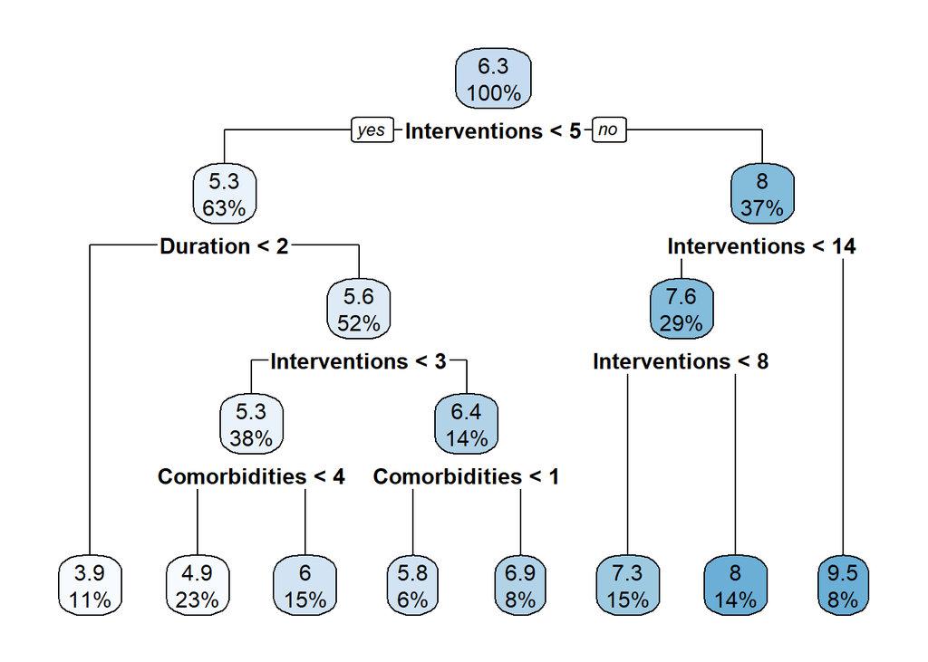

```r
library(rpart.plot)
rpart.plot(rpart.out)
```

## Question 4

Create a diagnostic plot, specifically, the test-set predicted responses ($y$-axis) versus the test-set observed responses ($x$-axis). The predictions were generated in Question 2. For enhanced readability, be sure to set the $x$ limits and the $y$ limits to be the same, and add a line of slope one to the plot. Does the plot seem strange to you? Remember that for a decision tree, this “strangeness” is a feature, not a bug. If you don’t know what causes it, call us over.

```r
suppressWarnings(library(tidyverse))
```

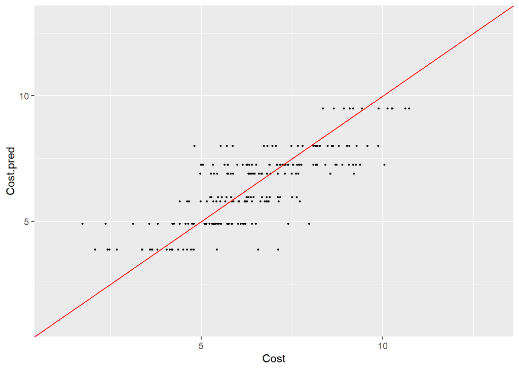

```r
ggplot(data = df.test, mapping = aes(x = Cost, y = Cost.pred)) +
  geom_point(size=0.5) +
  xlim(1, 13) +
  ylim(1, 13) +
  geom_abline(colour="red")
```

## Question 5

Run `plotcp()` with the output of your call to `rplot()` to see if the tree needs pruned. (Yes, it should be “needs to be pruned,” but you’re in Pittsburgh.) As a reminder, you are looking for the leftmost point that lies below the dotted line. If this is not the last point (the point farthest to the right), then `plotcp()` is trying to tell you to prune the tree. Note that depending on how you split the data, you may or may not see evidence that pruning is necessary.

Note that even if pruning is deemed necessary, you do not need to do that pruning here. You would, if necessary, go back to the code given in today’s notes to extract the pruned tree, which you can then use to, e.g., compute an MSE.

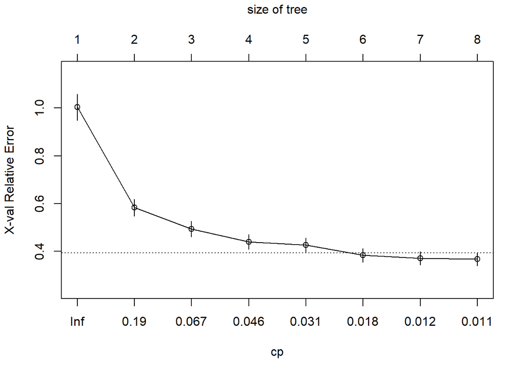

```r
plotcp(rpart.out)
```

# Classification Trees

Now we turn our attention to classification trees.

## Data, Part II

We will now load in the data on political movements that you looked at in the logistic regression lab:

```r
file.path <- "http://www.stat.cmu.edu/~pfreeman/movement.Rdata"
load(url(file.path))
f <- function(variable,level0="NO",level1="YES") {
  n <- length(variable)
  new.variable <- rep(level0,n)
  w <- which(variable==1)
  new.variable[w] <- level1
  return(factor(new.variable))
}
predictors$nonviol      <- f(predictors$nonviol)
predictors$sanctions    <- f(predictors$sanctions)
predictors$aid          <- f(predictors$aid)
predictors$support      <- f(predictors$support)
predictors$viol.repress <- f(predictors$viol.repress)
predictors$defect       <- f(predictors$defect)
levels(response)        <- c("FAILURE","SUCCESS")
rm(file.path,id.half,id,predictors.half)
summary(predictors)
```

```
##  nonviol     democracy        sanctions  aid      support   viol.repress
##  NO :149   Min.   :-10.0000   NO :179   NO :149   NO :159   NO : 27
##  YES: 69   1st Qu.: -7.0000   YES: 39   YES: 69   YES: 59   YES:191
##            Median : -3.0000
##            Mean   : -0.9404
##            3rd Qu.:  7.0000
##            Max.   : 10.0000
##  defect       duration
##  NO :157   Min.   :    2
##  YES: 61   1st Qu.:  360
##            Median :  730
##            Mean   : 1494
##            3rd Qu.: 1825
##            Max.   :17155
```

```r
summary(response)
```

```
## FAILURE SUCCESS
##     123      95
```

## Question 6

Split the data! Feel free to recreate what you did for Question 2 of the Lab 08R.

```r
set.seed(1)
s <- sample(nrow(predictors), round(0.7*nrow(predictors)))
pred.train <- predictors[s,]
pred.test <- predictors[-s,]
resp.train <- response[s]
resp.test <- response[-s]
```

## Question 7

Your next job is to learn a classification tree. Do that, and output a confusion matrix. (Note that the use of the `predict()` function might be, for you, a little different here: use `type="class"` as an argument, so that the output is not a probability but a classification. You can use the output directly when creating the confusion matrix.) What is the misclassification rate? (If you split your data in the same manner as you did for linear regression, is the MCR lower? Just make a mental note.)

```r
rpart.out = rpart(resp.train~.,data=pred.train)
resp.pred = predict(rpart.out,newdata=pred.test,type="class")

# create a confusion matrix
tab <- table(resp.pred, resp.test)
tab
```

```
##          resp.test
## resp.pred FAILURE SUCCESS
##   FAILURE      32       7
##   SUCCESS       8      18
```

```r
# misclassification rate
misrate.test <- 1-sum(diag(tab))/sum(tab)
misrate.test
```

```
## [1] 0.2307692
```

```
the misclassification rate is 0.23, which is lower than the one (0.28) for linear regression.
```

## Question 8

Let’s follow up on the material presented on Tuesday by computing the Area Under Curve (AUC) for the decision tree model. Dealing with prediction is a bit tricky as the argument change a bit from model to model, but what you’d want to do here is run

- resp.pred <- predict(rpart.out,newdata=pred.test,type=“prob”)[,2]

and then mimic the material presented in the notes on Tuesday to generate an AUC.

```r
library(pROC)
```

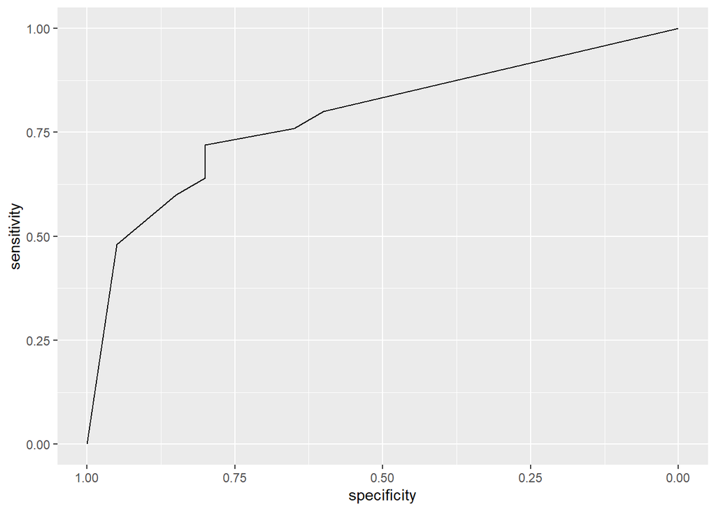

```r
library(ggplot2)
# extract prob of SUCCESS class
resp.pred <- predict(rpart.out,newdata=pred.test,type="prob")[,2]
roc.out = roc(resp.test, resp.pred)
ggroc(roc.out)
```

## Question 9

Plot your classification tree (perhaps with the argument `extra=104` or `extra=106`) and determine if pruning is necessary using `plotcp()`. Make a mental note about the pruning…but see Question 9.

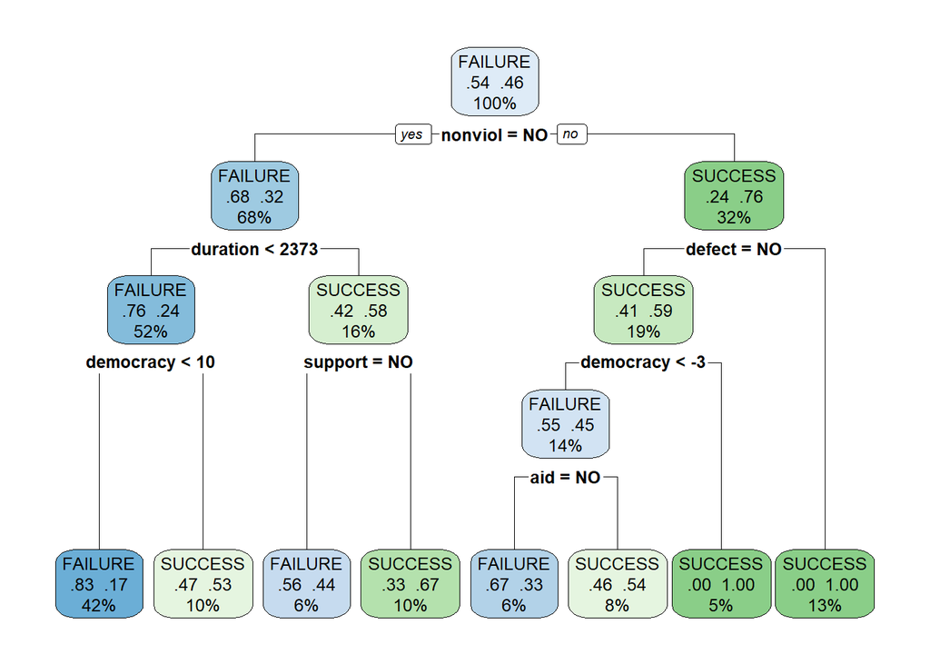

```r
# plot the classification tree
rpart.plot(rpart.out,extra=104)
```

## Question 10

Here, I suspect you saw clear evidence that pruning would be useful. Go ahead, prune the tree and replot the pruned tree. Also, compute the misclassification rate: did pruning make things worse?

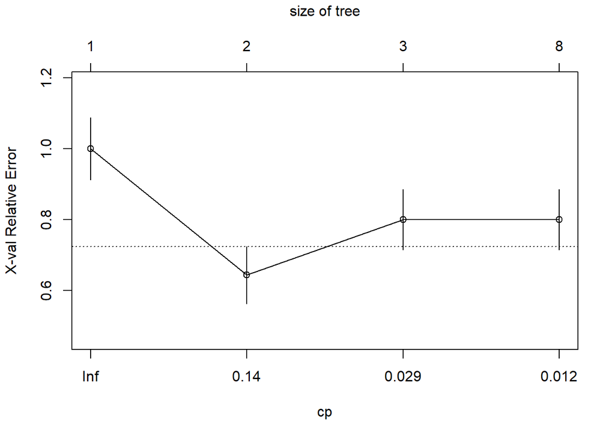

```r
# determine pruning
plotcp(rpart.out)
```

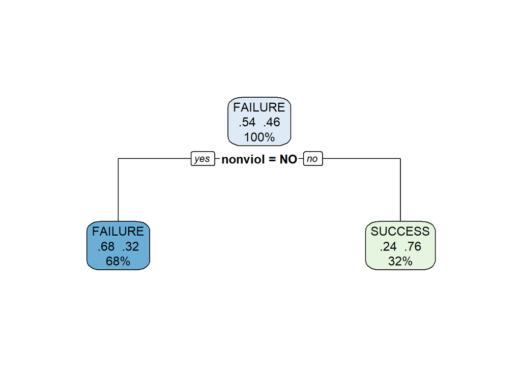

```r
# choose best cp
cp = rpart.out$cptable[which.min(rpart.out$cptable[,"xerror"]),"CP"]
# pruning
rpart.pruned <- prune(rpart.out, cp)
rpart.plot(rpart.pruned,extra=104)
```

```r
# predict
resp.pred = predict(rpart.pruned, newdata=pred.test,type="class")

# create a confusion matrix
tab.pruned <- table(resp.pred, resp.test)
tab.pruned
```

```
##          resp.test
## resp.pred FAILURE SUCCESS
##   FAILURE      34      11
##   SUCCESS       6      14
```

```r
# misclassification rate
misrate.pruned <- 1-sum(diag(tab))/sum(tab)
misrate.pruned
```

```
## [1] 0.2307692
```

[output not shown]